# Dependent data + AI evals

Julia Fukuyama

Simulation-Based Inference · Lecture 22

## Nonparametric bootstrap for dependent data

## Recall the nonparametric bootstrap

Suppose $X_1,\ldots,X_n$ are iid from an unknown distribution $P$.

- Estimate $P$ by $\hat P$, which puts mass $1/n$ on each observed $x_i$.
- Draw $n$ independent observations from $\hat P$ and recompute your estimate.
- Repeat to approximate the sampling distribution of the estimator.

This works well if the true data-generating process has $X_1,\ldots, X_n$ iid.

## How to recognize iid observations

If $U_1,\ldots,U_n$ are iid and we apply the same function to each one separately, then
$$X_i=g(U_i),\qquad i=1,\ldots,n$$
are iid.

The inputs and outputs can be vectors.

## Hierarchical dependence

Suppose we draw independent patients from the same population and take three measurements on each patient.

Our model might be:
$$\begin{aligned}
A_i &\overset{iid}{\sim} P_{patients} \\
E_{ij} &\overset{iid}{\sim} N(0, \sigma^2) \\
X_{ij} &= A_i + E_{ij} \qquad j = 1,2,3
\end{aligned}$$
where $A_i$ is a patient effect.

- Measurements from the same patient share $A_i$, so they are dependent.
- The **vectors** $(X_{i1},X_{i2},X_{i3})$ are iid across patients. Each is the same function of the iid random vectors $(A_i,E_{i1},E_{i2},E_{i3})$.

## The cluster bootstrap

Suppose $Z_1,\ldots,Z_n$ are iid clusters, and our estimate is $T(Z_1,\ldots,Z_n)$.

1. Put mass $1/n$ on each observed cluster.
2. Draw $n$ clusters with replacement. Each selected cluster brings along all its observations.
3. Recompute $T$ on the resulting dataset.

This is the ordinary nonparametric bootstrap applied to the iid objects in the model (the cluster vectors).

## What should we resample?

Suppose we survey people in several countries. What would we draw again if we repeated the study?

| Repeat the study with … | What to resample |
| --- | --- |
| The **same countries**, with a fresh sample of people in each | Keep the countries fixed. Resample people separately within each country, treating the people sampled there as iid. |
| A **fresh sample of countries**, with a survey in each | Treat each country’s survey data as one record. If those records are iid, resample whole country records, carrying along all the people in each selected record. |

## Why not resample both levels?

The cluster bootstrap treats each whole cluster record as one iid observation. It applies the ordinary nonparametric bootstrap to those records.

You might be tempted to look at a multilevel model and think that you should resample from both levels.

The observation that the clusters themselves are iid means that you don’t have to.

It’s also not helpful.

## Why not resample both levels?

Suppose we have $G$ clusters with $m$ observations each.

$$\begin{aligned}
Z_g &\overset{iid}{\sim} P \\
E_{gj} &\overset{iid}{\sim} N(0, \sigma^2) \\
Y_{gj} &= Z_g + E_{gj}, \qquad j = 1,\ldots, m
\end{aligned}$$

Now suppose that $P$ is just a point mass at $\mu$, so $Z_g=\mu$ for every cluster. Then all $Gm$ observations are iid from $N(\mu,\sigma^2)$.

Even though in truth, each “cluster” comes from a distribution with the same mean, the observed cluster means will be slightly different.

If we resample observations within a selected cluster in addition to resampling clusters, we add variation around its observed mean, which already varies by chance. This makes the bootstrap variance too large.

## Example: An AI reading-comprehension evaluation

Suppose an AI answers $m$ questions about each of $G$ passages:
$$\begin{aligned}
Z_g &\overset{\mathrm{iid}}{\sim} P,
&&g=1,\ldots,G,\\
E_{gj} &\overset{\mathrm{iid}}{\sim} N(0,\sigma^2),
&&g=1,\ldots,G,\quad j=1,\ldots,m,\\
Y_{gj}&=Z_g+E_{gj}.
\end{aligned}$$

All errors are independent of the $Z_g$.

Here $Y_{gj}$ is a numerical answer-quality score for question $j$ about passage $g$. The passage-specific mean $Z_g$ captures how well the AI “understands” that passage; $E_{gj}$ captures question-to-question variation. Questions about the same passage share $Z_g$, making their scores dependent when $Z_g$ varies.

## Try it with four passages

Each answer receives a continuous numerical score.

| Passage | Question scores |
| --- | --- |
| A | 8, 9, 10 |
| B | 6, 7, 8 |
| C | 1, 2, 3 |
| D | 3, 4, 5 |

```r
scores <- rbind(A = c(8, 9, 10), B = c(6, 7, 8),
                C = c(1, 2, 3), D = c(3, 4, 5))

## sample clusters
scores[sample(1:4, 4, replace = TRUE), ]
## sample independently
sample(as.vector(scores), 12, replace = TRUE)

B = 1000
cluster_boot <- replicate(n = B, mean(scores[sample(1:4, 4, replace = TRUE), ]))
naive_boot <- replicate(n = B, mean(sample(as.vector(scores), 12, replace = TRUE)))

plotting_df <- data.frame(x = c(cluster_boot, naive_boot),
                          type = rep(c("cluster_boot", "naive_boot"), each = B))
ggplot(plotting_df, aes(x = x, fill = type)) + geom_histogram(alpha = .5, position = "identity")
```

[output not shown]

## METR’s time horizon benchmark

This is a study of language models.

They took tasks from each of three task suites.

Each task was annotated with “family” information, describing something about what sort of task it was.

Each task also has information about how long it would take a reasonably expert human to complete it.

Then, for each combination of model and task, they checked whether the model could solve the task and recorded 0 or 1 for success or failure.

Source: Kwa et al. (2025), [*Measuring AI Ability to Complete Long Tasks*](https://arxiv.org/abs/2503.14499v1). Data: [METR’s public analysis repository](https://github.com/METR/eval-analysis-public).

## Data variability model 1

Hold the 17 agents fixed. Draw new suites, families within suites, and tasks within families:

$$\begin{aligned}
W_s &\sim P_{\mathrm{suite}},\\
U_{sf}\mid W_s &\sim P_{\mathrm{family}}(\cdot\mid W_s),\\
T_{sfi}\mid U_{sf} &\sim P_{\mathrm{task}}(\cdot\mid U_{sf}),\\
Y_{msfir}\mid T_{sfi} &\sim
\operatorname{Bernoulli}\big(p_m(T_{sfi})\big).
\end{aligned}$$

The indices identify suite $s$, family $f$ within that suite, task $i$ within that family, agent $m$, and attempt $r$.

Suites are drawn independently. At each subsequent level, draws are independent conditional on the preceding levels.

$T_{sfi}$ describes the whole task, including its human-time rating. Each agent’s success probability $p_m(T_{sfi})$ can depend on any aspect of the task.

## Data variability model 2

Another way ignores suites and treats the families as iid draws from one pooled population:

$$\begin{aligned}
U_f &\sim P_{\mathrm{family}},\\
T_{fi}\mid U_f &\sim P_{\mathrm{task}}(\cdot\mid U_f),\\
Y_{mfir}\mid T_{fi} &\sim
\operatorname{Bernoulli}\big(p_m(T_{fi})\big).
\end{aligned}$$

The indices identify family $f$, task $i$ within that family, agent $m$, and attempt $r$. Hold the 17 agents fixed.

Families are drawn independently. At each subsequent level, draws are independent conditional on the preceding levels.

Sampling from this model generates new families, new tasks within those families, and new attempts. The mix of suite origins among the sampled families can vary across benchmarks.

## METR: Estimator

$Y$

→

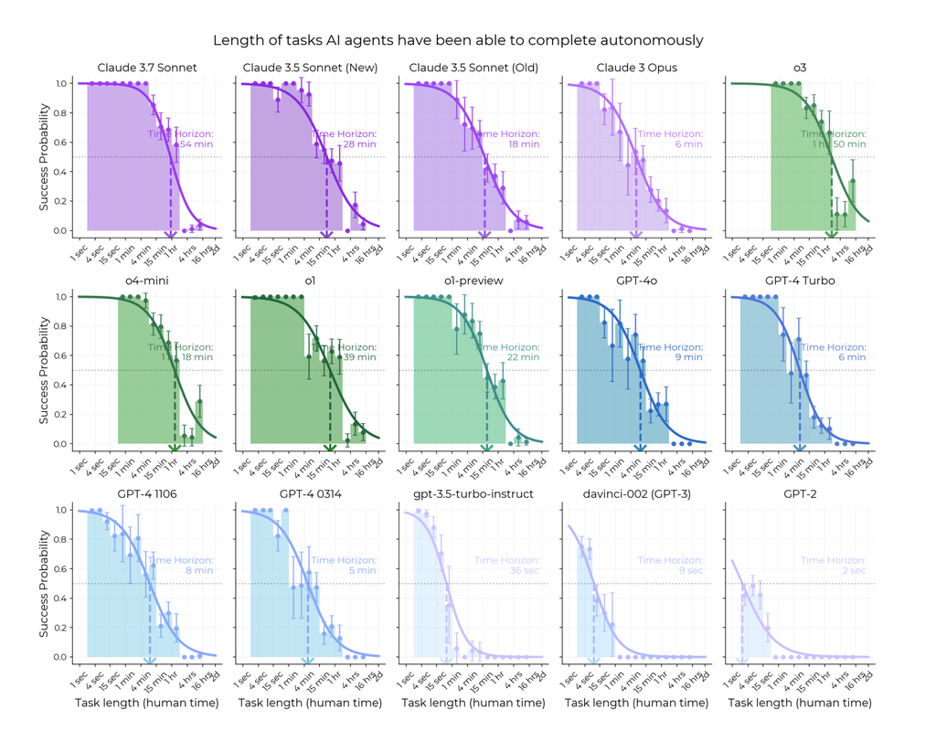

One logistic regression per agent; read off the 50% horizon $H_m$

→

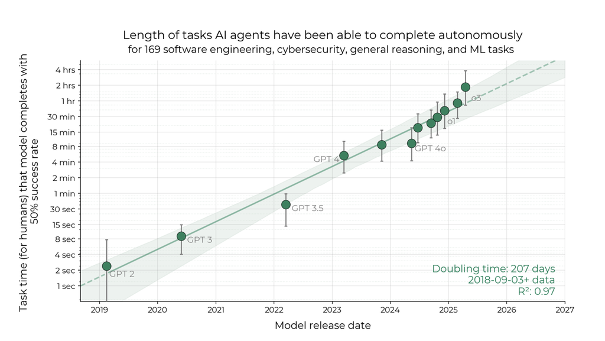

Plot $\log_2 H_m$ against release date $r_m$ and fit a line

Figures: Kwa et al. (2025), [*Measuring AI Ability to Complete Long Tasks*](https://arxiv.org/abs/2503.14499v1).

**Outputs:**

- The slope and intercept of the fitted line
- Doubling time
- Projected date for a one-month horizon

## METR: Uncertainty quantification

They use a cluster bootstrap using data model 2 above, so they resample families and ignore the task suites.

For every resample, they go through the procedure on the previous slide.

## Another way of thinking about this

I find it hard to think about what exactly this procedure is measuring.

Let’s try to think what a “real” generative model might look like.

We assume:

- Every model has some overall ability $A_m$, which is a function of release date + some noise
- Every task has some overall difficulty $D_i$, which is a function of the estimated time it takes a human to complete it plus some random offset for family-level difficulty plus some intrinsic error
- Once we have difficulties and model abilities, the probability of success on a given run is bernoulli with success probability that depends on the difference between model quality and task difficulty.

## A model

Task $i$ has human duration $h_i$, measured in hours, and belongs to family $F_i$. Set $x_i=\log_2 h_i$. Agent $m$ is released at date $r_m$ and has quality $A_m$.

$$\begin{aligned}
A_m &= \alpha+\gamma(r_m-r_0)+V_m, \qquad &&V_m
\overset{\mathrm{iid}}{\sim} N(0,\sigma_a^2),\\
D_i &= b x_i + U_{F_i}+E_i, \qquad &&U_F
\overset{\mathrm{iid}}{\sim}
N(0,\sigma_F^2),E_i\overset{\mathrm{iid}}{\sim} N(0,\sigma_d^2) \\
Y_{mi}\mid A_m,D_i &\sim
\operatorname{Binomial}(n_{mi},p_{mi}),\qquad
&&\operatorname{logit} p_{mi}=a_m-d_i .
\end{aligned}$$

The agent deviations $V_m$, family effects $U_F$, and task effects $E_i$ are mutually independent. Given these effects and the attempt counts, the success counts are independent.

## What does the baseline model project?

If we fit this sort of a model to the data and do the same sort of extrapolation, we get results that are roughly consistent with METR (modulo we’re using newer data and they didn’t report exactly the same things on the newer data.)

Question: Do the data actually look like they came from this model?

## Can the baseline reproduce the difficulty plot?

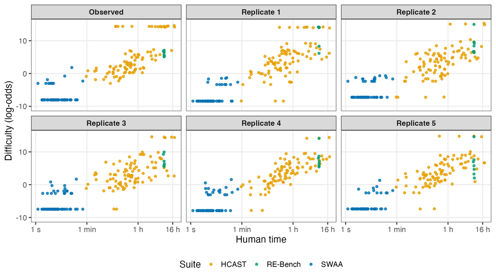

## What if some families are unusually hard?

Give each family a chance of an extra difficulty shift $\Delta>0$:

$$C_F\sim\operatorname{Bernoulli}(\pi),\qquad
U_F\mid C_F\sim N(C_F\Delta,\sigma_F^2).$$

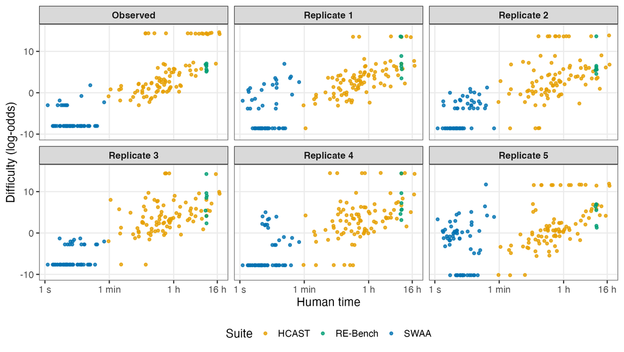

## What if hard families become more common with duration?

Let $\tilde h_F$ be the median human duration in family $F$, in hours. Replace the constant $\pi$ with

$$\begin{aligned}
C_F&\sim\operatorname{Bernoulli}(\pi_F),\\
\operatorname{logit}\pi_F&=\eta_0+\eta_1\log_2\tilde h_F,\qquad
\eta_1>0.
\end{aligned}$$

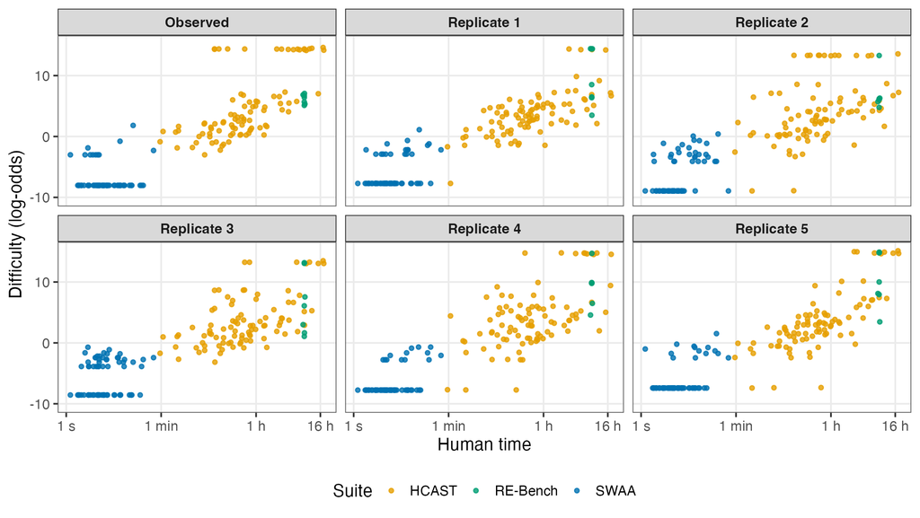

## Supplement: HCAST tasks only

From here on, we refit the models to the **HCAST tasks only**, using METR’s newer TH1.1 suite: 20 agents, 139 tasks, 60 families, 13,218 attempts.

We look at the baseline, the duration-dependent mixture, and one new model, with two checks for each:

- the response-only difficulty plot, as before;
- the never-solved vs always-solved tasks:
  - F: tasks longer than 1 minute that no agent ever solved.
  - S: tasks longer than 1 minute that every agent always solved.

## Baseline, HCAST only: difficulty

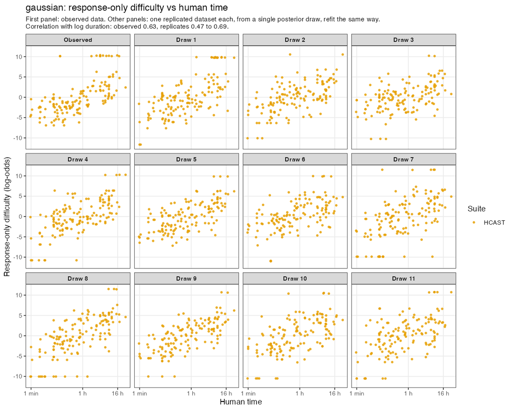

## Baseline, HCAST only: never-solved and always-solved tasks

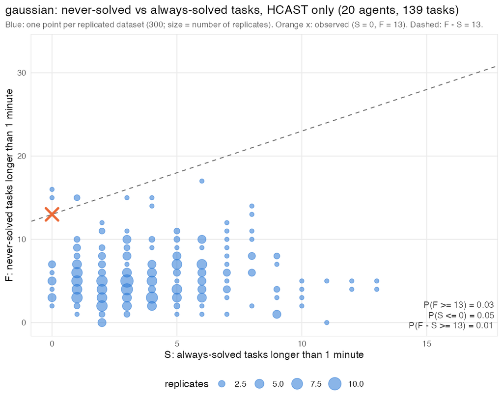

## Duration-dependent mixture, HCAST only: difficulty

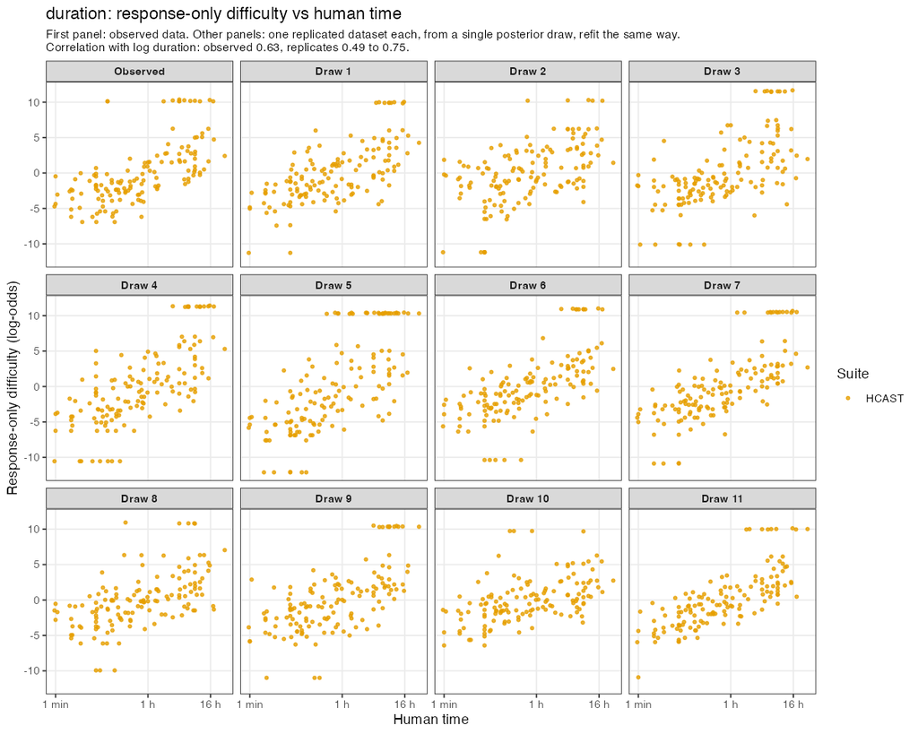

## Duration-dependent mixture, HCAST only: never-solved and always-solved tasks

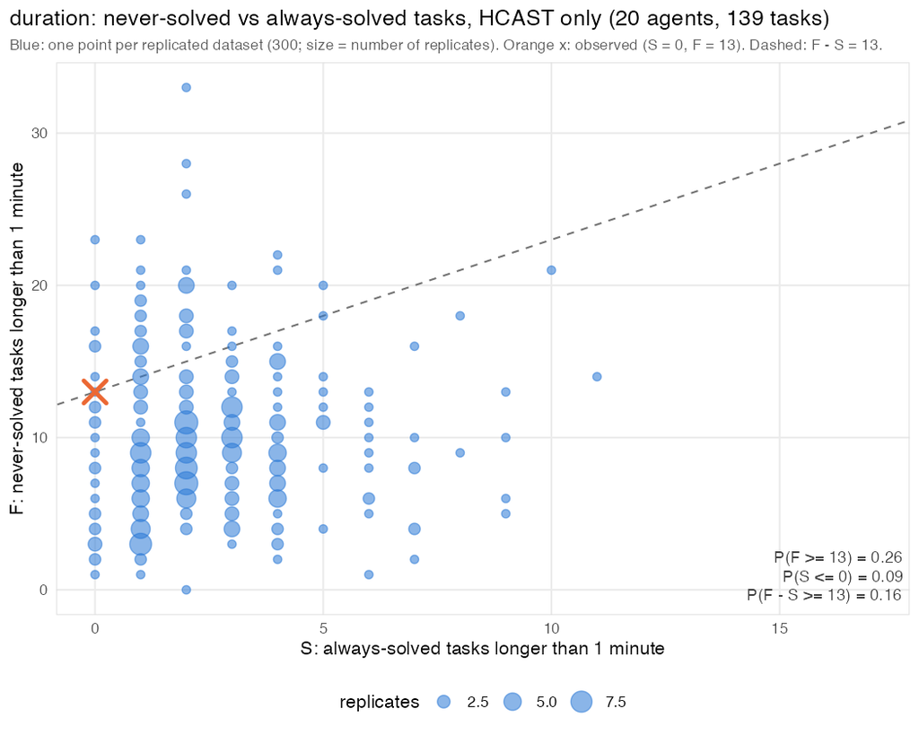

## What if the hard tail is continuous and grows with duration?

Replace the Gaussian family and task effects with split-normal effects, which have different SDs below and above 0:

$$\begin{aligned}
U_F&\sim\operatorname{SplitNormal}\!\left(0,\ \sigma_{F,L},\
\sigma_{F,R}\,e^{\rho_F\log_2\tilde h_F}\right),\\
E_i&\sim\operatorname{SplitNormal}\!\left(0,\ \sigma_{d,L},\
\sigma_{d,R}\,e^{\rho_d x_i}\right).
\end{aligned}$$

$\operatorname{SplitNormal}(0,\sigma_L,\sigma_R)$ has density proportional to the $N(0,\sigma_L^2)$ density below 0 and the $N(0,\sigma_R^2)$ density above 0.

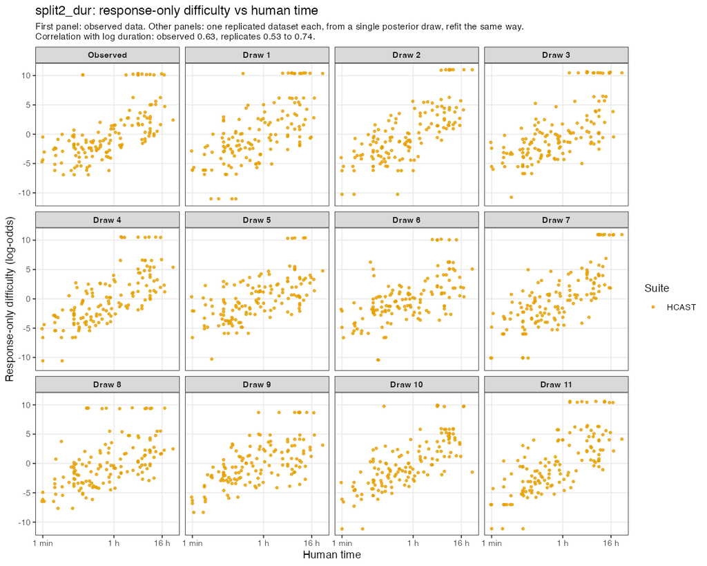

## Split-normal model, HCAST only: never-solved and always-solved tasks

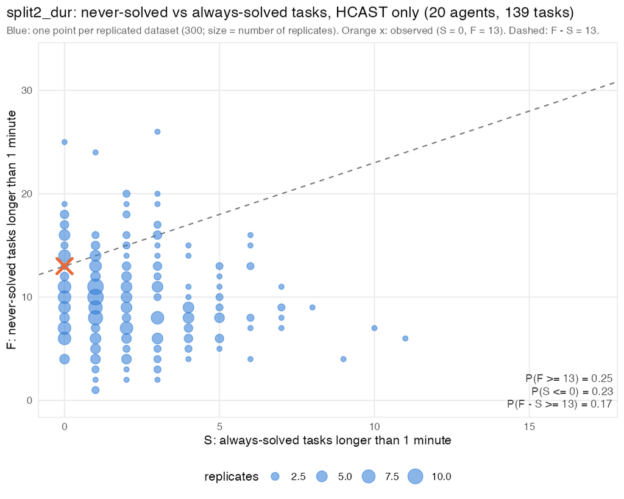

## How does the revised model change the projection?

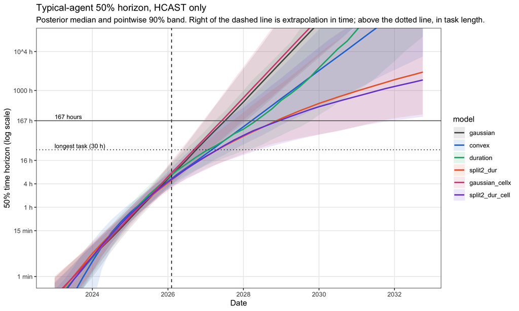